# 人工智能工程师招聘和薪酬水平

## 总述

本次采集有效数据5130条（城市发布量>=100）,主要分析人工智能相关岗位招聘和薪酬水平，如机器学习，深度学习，机器视觉，图像识别、图像处理，算法，语音识别等，我们将从如下方面分析：

- 01.城市分布：深圳占19%，平均月薪26416元；上海占19%，平均月薪26580元；广州占9%，平均月薪22609元；苏州占9%，平均月薪21119元；其余城市均在8%或以下。
- 02.行业分布：计算机软件占24%，平均月薪22378元；电子技术/半导体/集成电路占15%，平均月薪24376元；仪器仪表/工业自动化占15%，平均月薪20528元。
- 03.公司规模：1000人以下占82%，平均月薪23170元；1000-5000人占12%，平均月薪22979元；5000人以上占7%，平均月薪28616元。
- 04.公司类型：民营占65%，平均月薪23905元；外企占7%，平均月薪23283元。
- 05.工作经验：5年以下占89%，平均月薪22447元；5-10年占10%，平均月薪31068元。
- 06.学历要求：本科占60%，平均月薪22613元；硕士占31%，平均月薪26197%。
- 07.细分岗位：机器学习工程师平均月薪24138元；深度学习工程师平均月薪23886元，机器视觉工程师平均月薪19555元；其他岗位如图像算法、语音识别等可参考下面附图。

## 01.城市分布

[figure not shown]

roadmap

## 02.行业分布

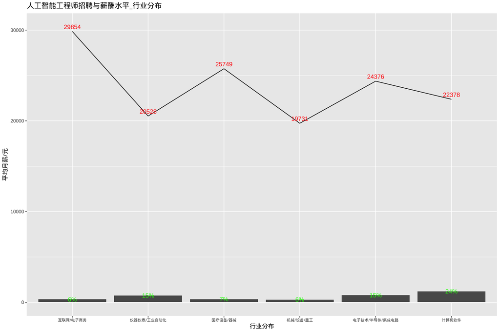

industries

## 03.公司规模

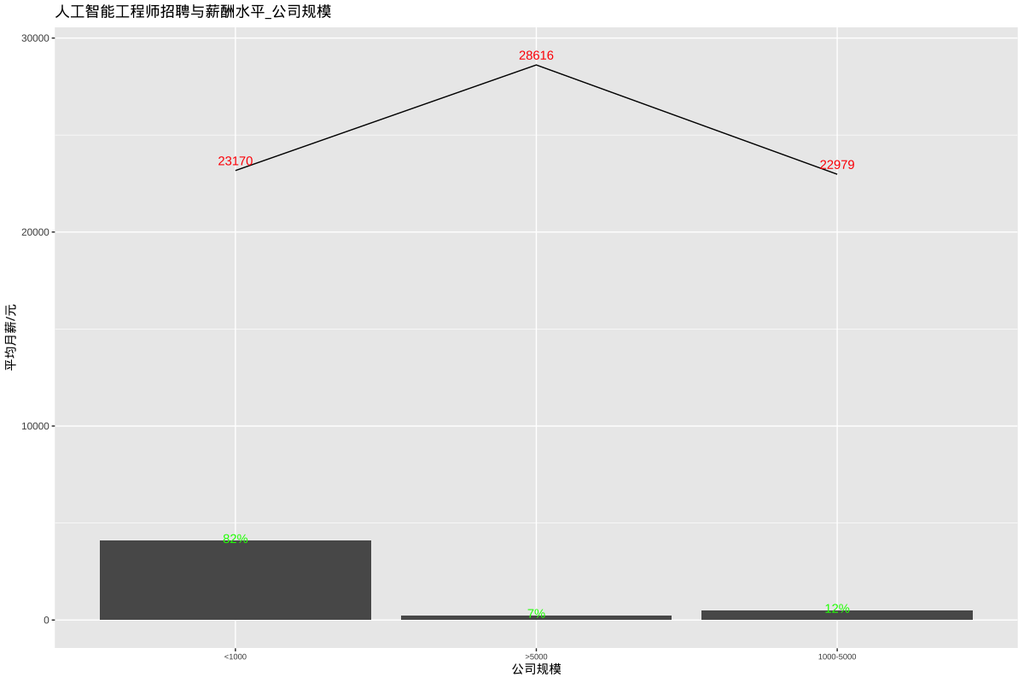

com_size

## 04.公司类型

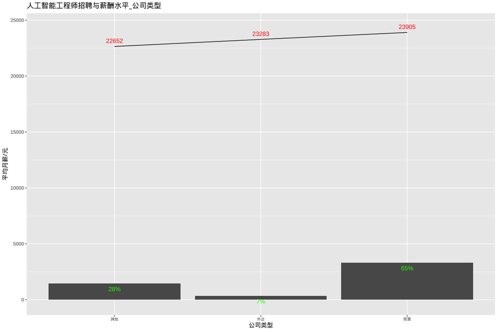

com_type

## 05.工作经验

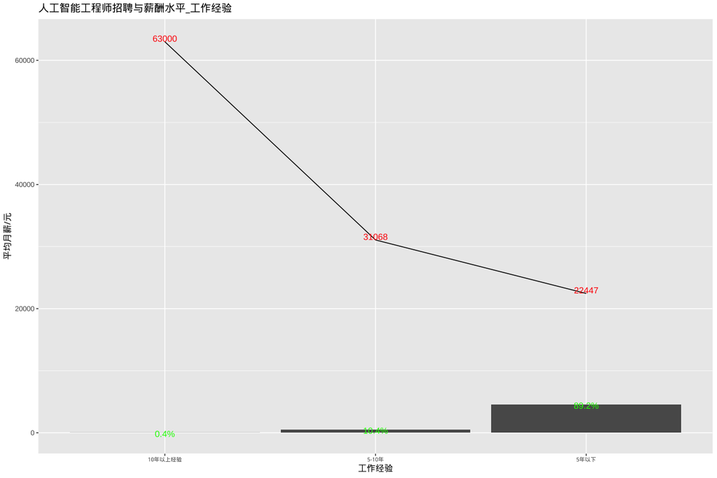

experience

## 06.学历要求

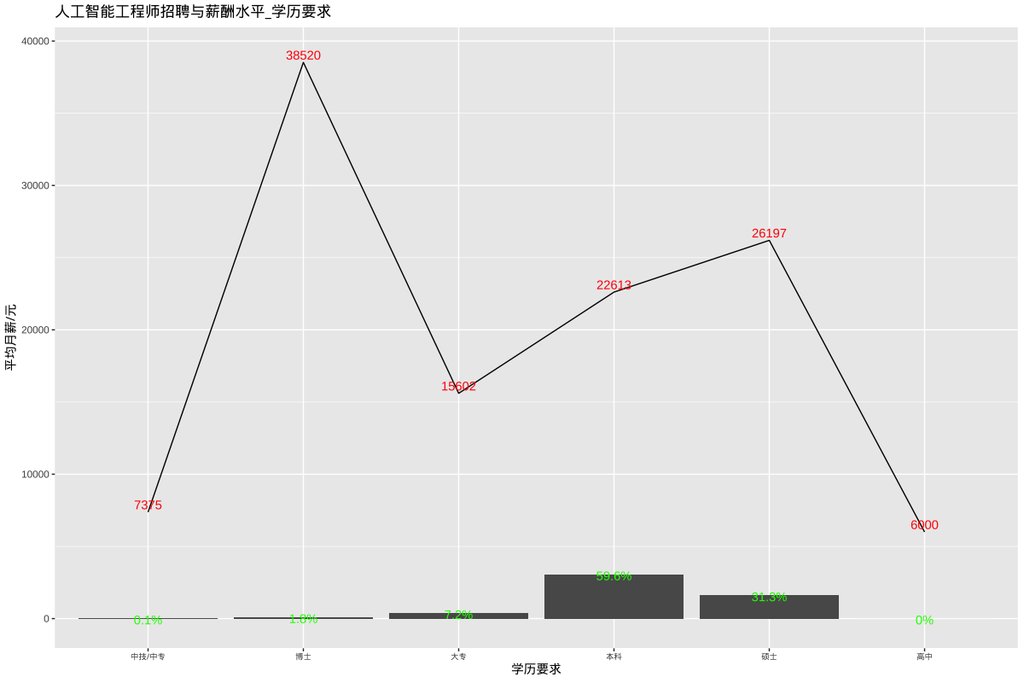

education

## 07.细分岗位

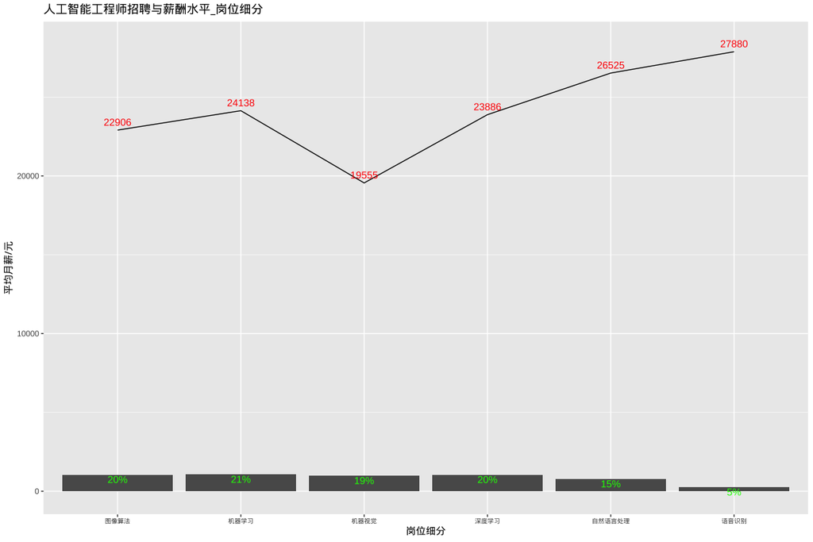

subclass